# Assignment4_RandomForests

Shania Sajan

2023-11-08

## Experiments with Random Forests

The following workflow includes the coding of a random forest model to create a model that will help predict the market direction for the years following 2019. The random forest model generates multiple base models in parallel. For each tree split, a sample of the predictors are used.

```r
# Load necessary libraries
library(tidyverse)
library(tidymodels)
library(doParallel)
library(knitr)
library(scales)
library(vip)
library(ranger)

NASDAQdt <- read_csv("nasdaq_lagged_2015_2019.csv")
```

Just like the boosting model, the same metrics are used, and the same process of splitting the data stays the same as well. Similarly, the cross-validation, and the choice of steps in the recipes.

```r
# Data Metrics
data_metrics <- metric_set(roc_auc, precision, recall, accuracy)

# Data Splits
set.seed(2673)
NASDAQdt_split <- initial_split(NASDAQdt, prop = 0.75, strata = Up_Down)
NASDAQ_train <- training(NASDAQdt_split)
NASDAQ_test <- testing(NASDAQdt_split)
```

```r
# Cross-validation folds
set.seed(548)
NASDAQ_folds <- vfold_cv(NASDAQ_train, v = 5, repeats = 5, strata = Up_Down)
```

```r
# Pre-processing Recipes
# Base Recipe
rf_base_recipe <- recipe(Up_Down ~ ., data = NASDAQdt) %>%
    step_zv(all_numeric_predictors()) %>%
    step_corr(all_numeric_predictors())
```

```r
# Enhanced Recipe
rf_enhanced_recipe <- recipe(Up_Down ~ ., data = NASDAQdt) %>%
  step_zv(all_numeric_predictors()) %>%
  step_corr(all_numeric_predictors()) %>%
  step_YeoJohnson(all_numeric_predictors())
```

When creating the rf model, we tune the trees and mtry elements as this searches for the combination of trees and mtry values that result in the best model performance, as measured by roc_auc. The “impurity” importance element in the creation of the model is important as it determines the best split at each node for random variables (importance = “impurity”).

```r
# Create Model
rf_model <-
    rand_forest(trees = tune(), mtry = tune()) %>%
    set_mode(('classification')) %>%
    set_engine('ranger', importance = "impurity")
```

```r
# Define Hyper-parameters
rf_grid <- grid_regular(
    trees(),
    finalize(mtry(), NASDAQ_train),
    levels = c(5,5))
```

```r
# Define workflow
rf_workflow_base <-
    workflow() %>%
    add_recipe(rf_base_recipe) %>%
    add_model(rf_model)

rf_workflow_enhanced <-
    workflow() %>%
    add_recipe(rf_enhanced_recipe) %>%
    add_model(rf_model)
```

```r
# Tune the Model
# Start a cluster
number_of_cores <- parallel::detectCores(logical = FALSE)
cluster <- makeForkCluster(number_of_cores)
registerDoParallel(cluster)

rf_control <- control_resamples(save_pred = TRUE)

rf_results_base <-
    rf_workflow_base %>%
    tune_grid(
        NASDAQ_folds,
        grid = rf_grid,
        metrics = data_metrics,
        control = rf_control
    )

rf_control <- control_resamples(save_pred = TRUE)

rf_results_enhanced <-
    rf_workflow_enhanced %>%
    tune_grid(
        NASDAQ_folds,
        grid = rf_grid,
        metrics = data_metrics,
        control = rf_control
    )

# Stop a cluster
stopCluster(cluster)
```

**Results**

```r
# Metrics
rf_results_base %>%
  show_best(metric = 'roc_auc') %>%
    kable(digits = 3, caption = "Best Models by Roc_Auc")
```

Best Models by Roc_Auc

| mtry | trees | .metric | .estimator | mean | n | std_err | .config |
| --- | --- | --- | --- | --- | --- | --- | --- |
| 1 | 1500 | roc_auc | binary | 0.546 | 25 | 0.006 | Preprocessor1_Model04 |
| 1 | 1000 | roc_auc | binary | 0.546 | 25 | 0.006 | Preprocessor1_Model03 |
| 1 | 2000 | roc_auc | binary | 0.546 | 25 | 0.007 | Preprocessor1_Model05 |
| 1 | 500 | roc_auc | binary | 0.545 | 25 | 0.007 | Preprocessor1_Model02 |
| 2 | 1000 | roc_auc | binary | 0.538 | 25 | 0.007 | Preprocessor1_Model08 |

```r
rf_results_enhanced %>%
  show_best(metric = 'roc_auc') %>%
    kable(digits = 3, caption = "Best Models by Roc_Auc")
```

Best Models by Roc_Auc

| mtry | trees | .metric | .estimator | mean | n | std_err | .config |
| --- | --- | --- | --- | --- | --- | --- | --- |
| 1 | 1000 | roc_auc | binary | 0.546 | 25 | 0.007 | Preprocessor1_Model03 |
| 1 | 500 | roc_auc | binary | 0.546 | 25 | 0.007 | Preprocessor1_Model02 |
| 1 | 1500 | roc_auc | binary | 0.546 | 25 | 0.007 | Preprocessor1_Model04 |
| 1 | 2000 | roc_auc | binary | 0.546 | 25 | 0.007 | Preprocessor1_Model05 |
| 2 | 1500 | roc_auc | binary | 0.539 | 25 | 0.007 | Preprocessor1_Model09 |

The random forest metrics above show a slight improvement within the model as it increases the mean by a little for one of the rows; moving from model 8 to 9.

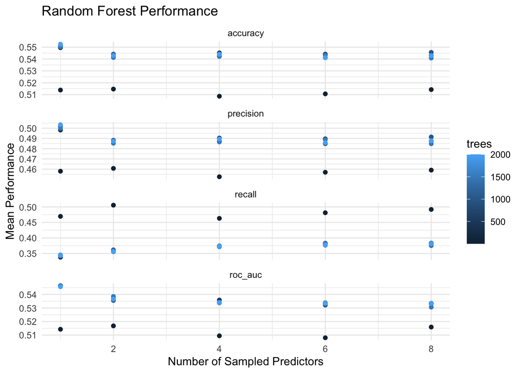

```r
# Visualize results
rf_metrics <- rf_results_enhanced %>%
    collect_metrics()

rf_metrics %>%
    ggplot(aes(x = mtry, y = mean, color = trees)) +
    geom_point() +
    facet_wrap(~ .metric, scales = 'free_y', ncol = 1) +
    labs(title = 'Random Forest Performance',
         x = 'Number of Sampled Predictors',
         y = 'Mean Performance') +
    theme_minimal()
```

```r
# Confusion Matrix
# Select best model
rf_best <- rf_results_enhanced %>%
    select_best(metric = 'roc_auc')

rf_best %>%
    kable(caption = 'Best Model', digits = 3)
```

Best Model

| mtry | trees | .config |
| --- | --- | --- |
| 1 | 1000 | Preprocessor1_Model03 |

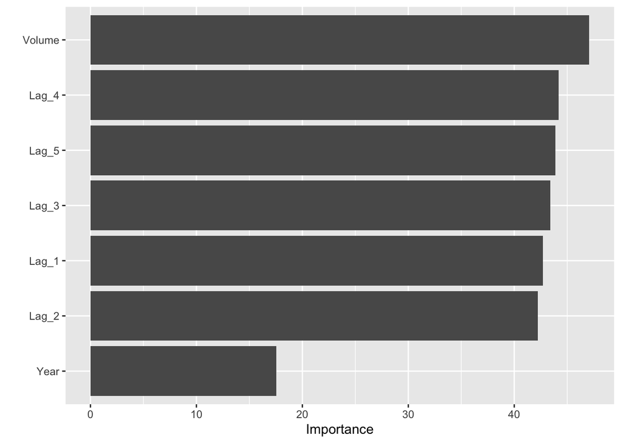

```r
# Feature Importance
rf_workflow_final <- rf_workflow_enhanced %>%
    finalize_workflow(rf_best)

rf_fit <- rf_workflow_final %>%
    fit(data = NASDAQ_train)

rf_fit %>%
  extract_fit_parsnip() %>%
  vip(num_features = 10)
```